# Computer exercise 1: solutions

**About this document.**

These are the solutions to Computer exercise 1: Survival analysis (`vignette("cs1-survival-analysis")`). The numbering is the same as in the exercise: the solutions are numbered 1-22, with the sub-parts keeping their letters, and the two bonus questions keep their headings.

Several solutions refer to output that is shown in the exercise — a table of the `survfit` output, a Kaplan-Meier figure, the log-rank printout. Keep both documents at hand, and use the numbering to match them. The code below is the code that produces the numbers quoted in the solutions.

## Data and software

The solutions need the same data and packages as the exercise, which documents the cohort and the variables (see `?scottish_mbc_cohort`).

```r
# The package with the course data sets is attached last, because several of its
# data sets have the same names as data sets in `survival` (for example
# `myeloma` and `ovarian`); the most recently attached package is the one that
# is found first.
library(tidyverse)
library(survival)
library(ggsurvfit)
library(gtsummary)
library(sta310)

mbc <- scottish_mbc_cohort
```

## 1. Time-to-event data and censoring

**1.**

1. The time origin is the **date of diagnosis** of metastatic breast cancer. In the data only `observed_time` is stored, but it is measured from diagnosis.
2. The time scale is **time since diagnosis**, measured in **months** (values such as 40.8 and 13.6 are months; the maximum is 71.2 months = about 6 years).
3. The event of interest is **death** (death from any cause, as the indicator is simply `status`).
4. `status = 0` means the patient was **right-censored**: she was still alive at the end of follow-up, so we only know that her true survival time is longer than `observed_time`.
5. Typical reasons: (i) **administrative censoring** — the patient was still alive when the study period ended / at data cut-off; (ii) **loss to follow-up** — the patient moved, transferred to another clinic or withdrew. In this synthetic cohort all censoring is administrative, but in real data both occur.

**2.**

```r
table(mbc$status)
```

```
#>
#>   0   1
#> 147 703
```

```r
mbc |>
  summarise(
    n = n(),
    deaths = sum(status == 1),
    censored = sum(status == 0),
    pct_censored = round(100 * mean(status == 0), 1),
    min_time = min(observed_time),
    max_time = max(observed_time)
  ) |>
  knitr::kable()
```

| n | deaths | censored | pct_censored | min_time | max_time |
| --- | --- | --- | --- | --- | --- |
| 850 | 703 | 147 | 17.3 | 0.5 | 71.2 |

There are **850 patients**, of whom **703 died** and **147 (17.3 %)** were censored. The observed follow-up times range from **0.5 to 71.2 months**. The censoring proportion is fairly low, which is typical for a metastatic cancer cohort with long follow-up: most patients experience the event within the study period.

**3.**

1. **False.** The patient contributes follow-up time up to 10 months and is then removed from the risk set. She is *not* at risk at 12 months. This is exactly how censoring enters the Kaplan–Meier estimator: censored subjects reduce the size of the risk set at later event times, but no event is counted for them.
2. **False.** Informative censoring can bias the estimate in **either direction**. If sicker patients drop out (e.g. because they become too unwell to attend), their future deaths are missing and survival looks *better* than it is (upward bias). If patients who are doing well leave the study, survival looks *worse* (downward bias). The sign depends on how censoring is related to prognosis.
3. **False.** The hazard is an **instantaneous rate**, not a probability. In the lecture $h(t) = \lim_{\Delta t \to 0} P(t \le T < t + \Delta t \mid T \ge t)/\Delta t$, so $h(t)$ can take any value from 0 to $\infty$ and is not bounded by 1. A probability of dying in a short interval would be approximately $h(t)\,\Delta t$.
4. **False.** Because survival times are right-skewed (a few long survivors), the median (and other percentiles) is preferred. The mean is influenced by the extreme tail and is often poorly estimated unless follow-up is complete.
5. **True.** *Left-censoring* means that the true event time is smaller than the observed time — for example, a patient who is first examined for a condition that had already started earlier. *Interval censoring* means that we only know that the event happened somewhere between two examination times. The MBC cohort has neither: here all censoring is right-censoring.

**4.**

Two things are lost in logistic regression:

- **Time.** Logistic regression only distinguishes “died” from “not died at the end of follow-up”. It does not use *when* the death occurred, so a patient who dies after 2 months and one who dies after 6 years contribute equally. Survival analysis uses the full follow-up time.
- **Censoring.** Patients who are censored are neither events nor properly “non-events”: we know only that they survived until their censoring time. Logistic regression would have to call them survivors, which treats incomplete follow-up as if it were complete, and this **overestimates survival** (see Question 8). Survival methods use the follow-up time of censored patients up to the point of censoring.

Moreover, survival time is positive and right-skewed, so ordinary linear regression of the time on the covariates is inappropriate too. The Cox model instead models the **hazard** and estimates **hazard ratios**, which is the natural effect measure for time-to-event data.

## 2. The survivor function and the Kaplan–Meier estimator

**5.**

- **Median survival** is **13.3 months** (95 % CI 12.3–15.1). This is the smallest event time at which the estimated survivor function has dropped to 0.5 or below: half of the patients have died within about 13 months of diagnosis.
- **$\hat S(12) = 0.542$** (95 % CI 0.510–0.577). An estimated 54 % of patients survive at least 12 months (1 year).
- **$\hat S(24) = 0.303$** (95 % CI 0.273–0.337). An estimated 30 % survive at least 24 months (2 years).

**6.**

1. The number at risk just before the time point is **626** at 6 months, **463** at 12 months and **207** at 24 months.
2. The curve **stays flat** at a censoring time. The Kaplan–Meier estimate only has steps (“drops”) at **event** times, where the factor $(1 - d_j/n_j) < 1$. At a censored observation $d_j = 0$, so the factor is $1$ and the estimate is unchanged; the only effect of censoring is that it **reduces the risk set** for later event times (and thereby increases the size of later steps).
3. The risk set shrinks for two reasons: patients die (events) *and* patients are censored. Between 6 and 24 months, for example, many patients both die and reach the end of their follow-up, so the number at risk falls from 626 to 207. Censoring removes people from the denominator without producing a step in the curve.

**7.**

The curve falls steeply during the first 12–24 months — the risk of death is highest shortly after the diagnosis of metastatic disease — and then flattens out. The horizontal line at $S = 0.5$ crosses the curve at the median, 13.3 months. After about 60 months the curve is almost flat: only a small subgroup of patients is still under observation, and few further deaths are observed among them.

**8.**

```r
deaths_24 <- sum(mbc$observed_time <= 24 & mbc$status == 1)
censored_24 <- sum(mbc$observed_time <= 24 & mbc$status == 0)

naive <- 1 - deaths_24 / nrow(mbc)
c(
  deaths_within_24 = deaths_24,
  censored_within_24 = censored_24,
  naive_2y = round(naive, 3)
)
```

```
#>   deaths_within_24 censored_within_24           naive_2y
#>            573.000             71.000              0.326
```

The naive estimate is $1 - 573/850 = 0.326$, compared with the Kaplan–Meier estimate $\hat S(24) = 0.303$. The naive value is **biased upwards**: **71 patients were censored before 24 months** and the formula silently counts them as if they had survived all 24 months, even though we do not know that. Kaplan–Meier removes them from the risk set at their censoring time instead.

The bias is modest here because only 17 % of the patients are censored. In a study with heavy censoring (e.g. short follow-up or many drop-outs) the naive estimate could be badly wrong, which is exactly why censoring-aware methods are needed.

**9.**

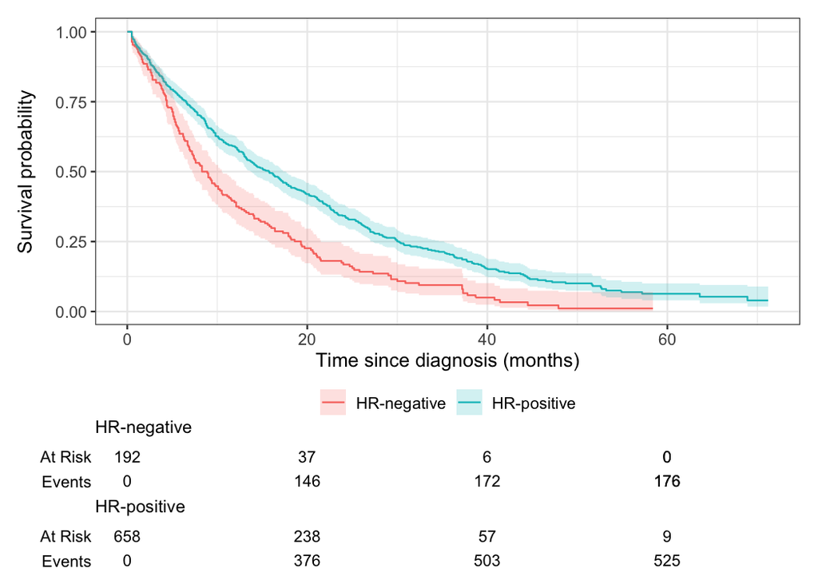

```r
km_hr <- survfit2(Surv(observed_time, status) ~ hormone_receptor, data = mbc)

km_hr |>
  ggsurvfit() +
  add_confidence_interval() +
  add_risktable() +
  labs(x = "Time since diagnosis (months)", y = "Survival probability")
```

```r
km_hr
```

```
#> Call: survfit(formula = Surv(observed_time, status) ~ hormone_receptor,
#>     data = mbc)
#>
#>                                n events median 0.95LCL 0.95UCL
#> hormone_receptor=HR-negative 192    176    8.6     7.2    10.5
#> hormone_receptor=HR-positive 658    527   15.7    13.7    17.6
```

Median survival is **8.6 months** (95 % CI 7.2–10.5) for HR-negative patients and **15.7 months** (95 % CI 13.7–17.6) for HR-positive patients. At 24 months, survival is 0.168 for HR-negative and 0.342 for HR-positive patients. The HR-positive curve lies clearly above the HR-negative curve throughout, so patients with hormone-receptor-positive tumours appear to live longer after a metastatic diagnosis. Whether the difference is statistically significant is tested in Question 12.

## 3. Hazard and cumulative hazard

**10.**

The HR-negative curve rises faster and stays above the HR-positive curve, so HR-negative patients accumulate risk (hazard) more quickly — consistent with their worse survival in Question 9. At 24 months the cumulative hazard is roughly $-\log(0.168) \approx 1.8$ for HR-negative and $-\log(0.342) \approx 1.07$ for HR-positive patients.

The **slope** of the cumulative hazard curve at a given time is the instantaneous hazard $h(t)$. A roughly straight cumulative hazard curve therefore corresponds to a roughly constant hazard (exponential-type survival); a steepening curve means the hazard is increasing over time.

**11.**

At 12 months the Nelson–Aalen estimate is 0.610 and $-\log \hat S(12) = 0.612$; at 24 months they are 1.189 and 1.194. $H(t) = -\log S(t)$ holds for the *true* functions in continuous time. Nelson–Aalen sums the increments $d_j/n_j$, whereas the Kaplan–Meier approach multiplies factors $(1 - d_j/n_j)$ and then takes the log; the difference is of second order in $d_j/n_j$ and is small when the risk set is large (i.e. for small $t$, large $n$). This matches the lecture’s remark that the two estimators give very similar results, especially for small $t$ with large $n$.

## 4. The log-rank test

**12.**

In the HR-negative group there were **176 observed deaths** against **119.0 expected** under the null hypothesis; in the HR-positive group there were **527 observed** against **584.0 expected**. HR-negative patients die more often than expected if the groups were the same, and HR-positive patients less often. The test statistic is $\chi^2 = 33.5$ on **1 degree of freedom**, **p = 7 ^{-9}**.

Conclusion: there is strong evidence that survival differs between the hormone-receptor groups, with **worse survival for HR-negative patients**. The log-rank test tells us that the groups differ; it does not by itself quantify the size of the difference — that is the job of the Cox model in Question 16.

**13.**

```r
survdiff(Surv(observed_time, status) ~ ecog_ps, data = mbc)
```

```
#> Call:
#> survdiff(formula = Surv(observed_time, status) ~ ecog_ps, data = mbc)
#>
#>             N Observed Expected (O-E)^2/E (O-E)^2/V
#> ecog_ps=0 248      190    255.6     16.85     27.08
#> ecog_ps=1 348      278    303.6      2.16      3.85
#> ecog_ps=2 192      176    113.6     34.26     42.04
#> ecog_ps=3  62       59     30.2     27.58     29.20
#>
#>  Chisq= 84  on 3 degrees of freedom, p= <2e-16
```

1. The null hypothesis is that **all four groups have the same survivor function**, $H_0: S_0(t) = S_1(t) = S_2(t) = S_3(t)$ for all $t$.
2. $\chi^2 = 84$ on **3 degrees of freedom**, **p < 2 ^{-16}**.
3. This is an **omnibus (overall) test**. A significant result says that at least one group differs from the others, but not **which** groups differ, nor **who differs from whom**. Nor does it quantify the size of the differences — for that you need pairwise comparisons (with a multiplicity adjustment) or a regression model with the ECOG groups as a categorical covariate, which also adjusts for other variables.

**Bonus (weighted tests).**

The **Wilcoxon-type test**, in R available as the Peto–Peto modification of the Gehan–Wilcoxon test through `survdiff(..., rho = 1)`, weights each death by $\hat S(t)^{\rho}$ with $\rho > 0$. With $\rho = 1$ late events are down-weighted relative to the log-rank test ($\rho = 0$), so early differences count more.

```r
survdiff(Surv(observed_time, status) ~ hormone_receptor, data = mbc, rho = 0) # log-rank
```

```
#> Call:
#> survdiff(formula = Surv(observed_time, status) ~ hormone_receptor,
#>     data = mbc, rho = 0)
#>
#>                                N Observed Expected (O-E)^2/E (O-E)^2/V
#> hormone_receptor=HR-negative 192      176      119     27.33      33.5
#> hormone_receptor=HR-positive 658      527      584      5.57      33.5
#>
#>  Chisq= 33.5  on 1 degrees of freedom, p= 7e-09
```

```r
survdiff(Surv(observed_time, status) ~ hormone_receptor, data = mbc, rho = 1) # Peto-Peto
```

```
#> Call:
#> survdiff(formula = Surv(observed_time, status) ~ hormone_receptor,
#>     data = mbc, rho = 1)
#>
#>                                N Observed Expected (O-E)^2/E (O-E)^2/V
#> hormone_receptor=HR-negative 192      111       76     16.33      28.2
#> hormone_receptor=HR-positive 658      294      329      3.77      28.2
#>
#>  Chisq= 28.2  on 1 degrees of freedom, p= 1e-07
```

The Peto–Peto test gives $\chi^2 = 28.2$, p = 1 × 10⁻⁷, still clearly significant, so the conclusion is unchanged. Here the log-rank test is slightly *more* significant, which is expected when the hazard ratio is roughly constant over time — that is precisely the situation in which the log-rank test is most powerful (Collett, Section 2.6.5).

**14.**

```r
event_times <- sort(unique(mbc$observed_time[mbc$status == 1]))

observed <- expected <- variance <- 0
for (t in event_times) {
  n <- sum(mbc$observed_time >= t) # all at risk at t
  n1 <- sum(mbc$observed_time >= t & mbc$hormone_receptor == "HR-negative") # at risk, HR-neg
  n2 <- n - n1 # at risk, HR-pos
  d <- sum(mbc$observed_time == t & mbc$status == 1) # deaths at t
  d1 <- sum(
    mbc$observed_time == t &
      mbc$status == 1 &
      mbc$hormone_receptor == "HR-negative"
  ) # deaths at t, HR-neg

  observed <- observed + d1
  expected <- expected + d * n1 / n
  if (n > 1) {
    variance <- variance + d * (n - d) * n1 * n2 / (n^2 * (n - 1))
  }
}

c(
  observed = observed,
  expected = round(expected, 2),
  o_minus_e_sq_over_e = round((observed - expected)^2 / expected, 2),
  o_minus_e_sq_over_v = round((observed - expected)^2 / variance, 2)
)
```

```
#>            observed            expected o_minus_e_sq_over_e o_minus_e_sq_over_v
#>              176.00              118.98               27.33               33.51
```

The loop gives $O = 176$ and $E = 118.98$, matching the `survdiff()` table (176 and 119.0). The $(O-E)^2/E$ component is 27.33 and $(O-E)^2/V$ is 33.51, which is the test statistic $\chi^2 = 33.5$ reported by `survdiff()` (for two groups $(O-E)^2/V$ is the correct statistic; the $(O-E)^2/E$ column is only a descriptive component).

**15.**

Use a **stratified log-rank test**, which performs the comparison within each stratum of ECOG performance status and then combines the strata. It adjusts for ECOG without assuming proportional hazards across ECOG levels (though it still assumes proportional hazards between the hormone-receptor groups within strata).

```r
survdiff(
  Surv(observed_time, status) ~ hormone_receptor + strata(ecog_ps),
  data = mbc
)
```

```
#> Call:
#> survdiff(formula = Surv(observed_time, status) ~ hormone_receptor +
#>     strata(ecog_ps), data = mbc)
#>
#>                                N Observed Expected (O-E)^2/E (O-E)^2/V
#> hormone_receptor=HR-negative 192      176      114     33.14        41
#> hormone_receptor=HR-positive 658      527      589      6.44        41
#>
#>  Chisq= 41  on 1 degrees of freedom, p= 2e-10
```

Stratifying on ECOG gives $\chi^2 = 41$ on 1 degree of freedom, **p = 2 ^{-10}$**, compared with $\chi^2 = 33.5$ unadjusted. The evidence for a difference between hormone-receptor groups is actually **slightly stronger** after adjusting for ECOG, so the hormone-receptor effect is not explained by a different distribution of performance status between the groups.

## 5. Cox proportional hazards regression

**16.**

1. HR (HR-positive vs HR-negative) = **0.604**, 95 % CI **0.509–0.718**, **p = 9.7 ^{-9}**.
2. At any point in time, HR-positive patients have about **40 % lower hazard** of death than HR-negative patients (0.60 times the hazard), i.e. they die at about 60 % of the rate of HR-negative patients.
3. The reference level is HR-negative, so the HR for HR-negative versus HR-positive is $1/0.604 = 1.66$: HR-negative patients have about **a 66 % higher hazard** of death. Note that this is *not* the same as saying that they are “66 % more likely to die” within a given time.
4. The p-value (9.7 × 10⁻⁹) is very close to the log-rank p-value (7 × 10⁻⁹). This is not a coincidence: the score test of the Cox model with a single binary covariate is essentially the log-rank test. The Cox model adds an **effect estimate** (the hazard ratio), which the log-rank test does not provide.

**17.**

```r
mbc_model <- mbc |>
  mutate(
    ecog_ps = factor(ecog_ps),
    age_dec = age_at_diagnosis / 10
  )

cox_multi <- coxph(
  Surv(observed_time, status) ~ hormone_receptor +
    her2_status +
    n_metastatic_sites +
    ecog_ps +
    age_dec,
  data = mbc_model
)

tbl_regression(cox_multi, exponentiate = TRUE)
```

| **Characteristic** | **HR** | **95% CI** | **p-value** |
| --- | --- | --- | --- |
| hormone_receptor |  |  |  |
| HR-negative | — | — |  |
| HR-positive | 0.55 | 0.46, 0.66 | <0.001 |
| her2_status |  |  |  |
| Negative | — | — |  |
| Positive | 0.88 | 0.72, 1.07 | 0.2 |
| n_metastatic_sites | 1.25 | 1.17, 1.34 | <0.001 |
| ecog_ps |  |  |  |
| 0 | — | — |  |
| 1 | 1.31 | 1.08, 1.58 | 0.005 |
| 2 | 2.49 | 2.01, 3.08 | <0.001 |
| 3 | 2.80 | 2.08, 3.77 | <0.001 |
| age_dec | 1.16 | 1.09, 1.24 | <0.001 |

Abbreviations: CI = Confidence Interval, HR = Hazard Ratio

Interpretation (adjusted for all other variables in the model):

- **Hormone receptor status:** HR-positive vs HR-negative HR = **0.55** (95 % CI 0.46–0.66), p = 2.3 × 10⁻¹¹. HR-positive patients have about a 45 % lower hazard of death.
- **HER2 status:** HR = **0.88** (0.72–1.07), p = 0.21 — no clear evidence of an association after adjustment.
- **Number of metastatic sites:** HR = **1.25** (1.17–1.34), p = 1.0 × 10⁻¹⁰ per additional site — each extra metastatic site is associated with a 25 % higher hazard.
- **ECOG performance status** (reference = 0): HR = **1.31** (1.08–1.58) for PS 1; **2.49** (2.01–3.08) for PS 2; **2.80** (2.08–3.77) for PS 3. There is a strong, monotone association: worse performance status means a higher hazard.
- **Age:** HR = **1.16** (1.09–1.24), p = 2.0 × 10⁻⁶ per 10 years — older patients have a higher hazard of death.

So hormone receptor status, number of metastatic sites, performance status and age are all associated with survival after adjustment, whereas HER2 status is not clearly associated in this cohort.

**Bonus (variable selection).**

Stepwise selection uses the **same data twice**: first to choose the variables and then to estimate and test their effects. The reported p-values and confidence intervals then behave as if the model had been specified in advance, so they are **too optimistic** (the true uncertainty is larger). The selected model is also **unstable** — small changes in the data can change which variables enter — and it ignores subject-matter knowledge in favour of mechanical p-value thresholds.

A better approach is to pre-specify the covariates from clinical knowledge (as in Question 17), or to use a method that accounts for the selection, such as penalised regression (the lasso for Cox models, Collett Section 3.7) combined with validation. Automatic selection is best used as an exploratory tool, not as the final analysis.

**19.**

```r
logit_hr <- glm(status ~ hormone_receptor, data = mbc, family = binomial)
exp(cbind(OR = coef(logit_hr), confint(logit_hr)))
```

```
#>                                     OR     2.5 %     97.5 %
#> (Intercept)                 11.0000000 6.8162412 19.1015480
#> hormone_receptorHR-positive  0.3657183 0.2044375  0.6139977
```

1. The odds ratio is **0.366** for HR-positive vs HR-negative (95 % CI 0.204–0.614), i.e. **2.73** for HR-negative vs HR-positive. The corresponding hazard ratio was **1.66**. The odds ratio is clearly larger.
2. The two measures answer different questions. The **odds ratio** compares the odds of being dead *at the end of follow-up* — a cumulative, time-averaged quantity that depends on how long the study ran. The **hazard ratio** compares the instantaneous rate of death at any given time among those still alive. For a common outcome (here 83 % of patients died) the odds ratio moves away from 1 much faster than the hazard ratio, so it is not a good approximation of the relative risk or hazard. Logistic regression also ignores *when* patients died and treats censored patients as survivors.
3. The statement has several problems:
- *“2.5 times more likely”* is a **relative-risk** interpretation. A hazard ratio is a ratio of **rates**, not of probabilities; it does not mean 2.5 times the probability of dying.
- The number 2.5 does not correspond to any estimate here (the OR is 2.73, the HR is 1.66), so it is unclear what it refers to.
- There is **no time frame**: “more likely to die” by when? By 1 year, 2 years, or ever?
- If the number came from the logistic model it also **ignores censoring**, so it is biased.

## 6. Checking the proportional hazards assumption

**20.**

The HR-negative curve remains consistently above the HR-positive curve, indicating poorer survival among HR-negative patients. The curves are close together initially, but the vertical distance increases during the first 10–15 months. Thereafter, the curves appear approximately parallel, although some variation in their separation remains. The confidence intervals widen towards the end of follow-up, particularly for the HR-negative group, where fewer patients remain at risk. Overall, the plot suggests some variation in the hazard ratio over time, particularly early in follow-up, but no strong evidence of a substantial violation of the proportional hazards assumption. This is consistent with the formal test in Question 21, which provides no statistical evidence against proportional hazards for hormone_receptor.

Note that the curves become unstable at the far right (few patients at risk), so judgement should focus on the region where the risk set is adequate.

**21.**

```r
cox.zph(cox_multi)
```

```
#>                     chisq df     p
#> hormone_receptor    0.620  1 0.431
#> her2_status         5.098  1 0.024
#> n_metastatic_sites  2.076  1 0.150
#> ecog_ps             2.800  3 0.423
#> age_dec             0.242  1 0.623
#> GLOBAL             10.593  7 0.157
```

1. `cox.zph()` tests, for each covariate, whether its effect changes over time (null hypothesis: no time-varying effect, i.e. proportional hazards holds). Here `hormone_receptor` p = 0.43, `n_metastatic_sites` p = 0.15, `ecog_ps` p = 0.42 and `age_dec` p = 0.62 are all non-significant, while **`her2_status` has p = 0.024**. The `GLOBAL` test (p = 0.157) is not significant.
2. The assumption looks acceptable for the main predictors. The one figure worth a comment is HER2: there is some evidence that its effect varies over time. That said, HER2 was not clearly associated with survival to begin with (p = 0.21), so the practical impact is limited. The `GLOBAL` test gives no overall reason to abandon the proportional hazards model. A careful analysis would still inspect the Schoenfeld residual plot for HER2 (`plot(cox.zph(cox_multi)[2])`) to see how the effect changes, and report the HER2 hazard ratio as a time-averaged effect with this caveat.

**22.**

Two standard strategies:

- **Stratification.** Include the variable as a stratification factor instead of a covariate, `coxph(Surv(time, status) ~ x + strata(z), data = ...)`. This allows the baseline hazard to differ between the levels of $z$ without estimating its effect. You do not get a hazard ratio for $z$ itself, but you get valid, adjusted hazard ratios for the other covariates. It works best for a categorical variable with few levels and when its effect is not of primary interest.
- **A time-varying effect.** Model the coefficient as a function of time, e.g. by adding an interaction between the covariate and a function of time (Collett, Section 4.4.4), or by a time-dependent coefficient model. This yields an effect estimate that **changes over time**, so the single “average” hazard ratio is replaced by a description of how the hazard ratio evolves.

Others: report the hazard ratio as a **time-averaged** effect with an explicit caveat; or switch to a model that does not require proportional hazards, such as an accelerated failure time / parametric model (Chapters 5–7) or a restricted mean survival time analysis. Whatever the choice, the important point is that a non-proportional effect should not be reported as a single constant hazard ratio without comment.